# Identity Encoding Code 04:

Assessing Repeated Individual Sampling at the Site Scale

[Grace Smith-Vidaurre](http://smith-vidaurre.com/)<sup>1-4*</sup> <sup>1</sup>Department of Biology, New Mexico State University <sup>2</sup>Laboratory of Neurogenetics of Language, Rockefeller University <sup>3</sup>Field Research Center, Rockefeller University <sup>4</sup>Department of Biological Sciences, University of Cincinnati *gsvidaurre@gmail.com

12 June, 2023

This code accompanies the following paper in PLOS Computational Biology:

Smith-Vidaurre, G., Perez-Marrufo, V., Hobson, E.A., Salinas-Melgoza, A., and T.F. Wright. 2023. Individual identity information persists in learned calls of introduced parrot populations.

Here we assessed our clustering and visual classification methods for identifying potential repeated sampling of individuals at the site scale in each of the native and introduced ranges. We assessed multi-observer reliability and the number of potential repeated individuals as well as the number of calls for each of these potentially repeatedly sampled birds that were identified in each range. See the methods and appendix of the associated publication for more information about these analyses.

Check out Github repositories from previous work for related analyses and code:

- gsvidaurre/strong-individual-signatures<sup>[1]</sup>
- gsvidaurre/simpler-signatures-post-invasion<sup>[2]</sup>

Please cite the associated papers and code (see DOIs on GitHub) if the code or analyses in these 3 repositories are useful for your own research.

Clean environment, load packages, initialize fundamental objects.

```r
rm(list = ls())

X <- c("ggplot2", "pbapply",  "dplyr", "data.table", "tidyverse", "rlist", "rdrop2", "plotrix", "Rmisc", "grid", "gridExtra", "egg", "ggplotify", "pracma", "irr", "knitr")

invisible(lapply(X, library, character.only = TRUE))

# Suppress summarise warnings from dplyr
options(dplyr.summarise.inform = FALSE)

path <- "/media/gsvidaurre/MYIOPSITTA/R/VocalLearning_PostDisruption/Data"
seed <- 401
cores <- parallel::detectCores() - 2
# cores

# Dropbox authorization token and path
app_path <- "/home/gsvidaurre/Desktop/GitHub_repos/vocal-learning-invasion/pot-rep-indiv-filter"
token <- readRDS(file.path(app_path, "token.rds"))
drop_path <- "Smith-Vidaurre_Grace/CulturalEvolution_PostInvasion/Detect_RepeatedIndividualSampling"
gpath <- "/media/gsvidaurre/MYIOPSITTA/R/VocalLearning_PostDisruption/Graphics"
```

Read in the extended selection table (EST) that contains metadata and wave objects for pre-processed native and introduced range calls across the individual and site scales.

```r
nat_int_est <- readRDS(file.path(path, "monk_parakeet_contactCalls_rangeComparison_extSelTable.RDS"))
glimpse(nat_int_est)
```

```
## Rows: 1,596
## Columns: 26
## $ sound.files          <chr> "2017_07_17_EMBR_INDIV-RAW_MZ000199_1.WAV", "2017…
## $ selec                <dbl> 1, 1, 1, 1, 1, 1, 1, 1, 1, 1, 1, 1, 1, 1, 1, 1, 1…
## $ start                <dbl> 0.05, 0.05, 0.05, 0.05, 0.05, 0.05, 0.05, 0.05, 0…
## $ end                  <dbl> 0.2646363, 0.2310324, 0.2509257, 0.2378781, 0.220…
## $ date                 <date> 2017-07-17, 2017-07-17, 2017-07-17, 2017-07-17, …
## $ range                <chr> "Native", "Native", "Native", "Native", "Native",…
## $ social_scale         <chr> "Individual", "Individual", "Individual", "Indivi…
## $ site                 <chr> "EMBR", "EMBR", "EMBR", "EMBR", "EMBR", "EMBR", "…
## $ Bird_ID              <chr> "NAT-RAW", "NAT-RAW", "NAT-RAW", "NAT-RAW", "NAT-…
## $ lat                  <dbl> -34.44437, -34.44437, -34.44437, -34.44437, -34.4…
## $ lon                  <dbl> -57.72845, -57.72845, -57.72845, -57.72845, -57.7…
## $ Visual_quality_score <fct> H, M, H, H, M, M, M, H, M, H, H, H, M, M, H, H, H…
## $ Overlapping_signal   <fct> N, N, N, N, N, N, N, N, N, N, N, N, N, N, N, N, N…
## $ Truncated            <chr> "N", "N", "N", "N", "N", "N", "N", "N", "N", "N",…
## $ tailored             <fct> y, y, y, y, y, y, y, y, y, y, y, y, y, y, y, y, y…
## $ prev_SNR             <dbl> 20.10350, 14.90409, 18.55063, 18.49727, 18.74672,…
## $ SNR_margin_works     <chr> "Y", "Y", "Y", "Y", "Y", "Y", "Y", "Y", "Y", "Y",…
## $ SNR_before_only      <chr> NA, NA, NA, NA, NA, NA, NA, NA, NA, NA, NA, NA, N…
## $ old.sound.file.name  <chr> "2017_07_17_EMBR_INDIV-RAW_MZ000199_1.WAV", "2017…
## $ SNR                  <dbl> 23.45415, 22.14815, 15.36660, 19.25200, 21.86770,…
## $ region               <chr> "West", "West", "West", "West", "West", "West", "…
## $ country              <chr> "Uruguay", "Uruguay", "Uruguay", "Uruguay", "Urug…
## $ site_year            <chr> "EMBR_2017", "EMBR_2017", "EMBR_2017", "EMBR_2017…
## $ year                 <chr> "2017", "2017", "2017", "2017", "2017", "2017", "…
## $ dept_state           <chr> "Colonia", "Colonia", "Colonia", "Colonia", "Colo…
## $ introduced_city      <chr> NA, NA, NA, NA, NA, NA, NA, NA, NA, NA, NA, NA, N…
```

# Get Shiny classification data

See the associated manuscript for more information on the Shiny app used for visual classification. Download co-authors’ data on the Shiny app classifications from Dropbox.

```r
drop_files <- drop_dir(drop_path) %>%
  dplyr::select(name) %>%
  pull(name)

drop_files

# Iterate over the files and download them from Dropbox one by one
invisible(pblapply(1:length(drop_files), function(x){
  drop_download(path = file.path(drop_path, drop_files[x]), dtoken = token, local_path = path, overwrite = TRUE)
}))
```

Read in the .json files and concatenate results into a single data frame.

```r
# Retain each .fson file for co-author. For VP, used the most recent file vp-2020-05-18_18-50-40.json
file_nms <- list.files(path, pattern = ".json$")
file_nms
```

```
## [1] "asm-2020-04-09_19-12-47.json" "dlh-2020-04-28_14-23-46.json"
## [3] "eah-2020-04-10_12-25-58.json" "gsv-2020-04-23_09-39-43.json"
## [5] "tfw-2020-05-07_20-34-18.json" "vp-2020-05-18_18-50-40.json"
```

```r
users <- sapply(1:length(file_nms), function(i){
  strsplit(file_nms[i], split = "-")[[1]][1]
})
users
```

```
## [1] "asm" "dlh" "eah" "gsv" "tfw" "vp"
```

# Training accuracy

Training accuracy summary statistics across users. Here, pulled training classification accuracy from the last training round before testing only. Note that ASM’s training data was only partially saved (see below).

```r
# Extract calls across classes and compare to the number of input calls
# Initialize testing data
train_imgs <- read.csv(file.path(app_path, "training_images.csv"))
# glimpse(train_imgs)

train_accur <- rbindlist(lapply(1:length(users), function(x){

  res <- list.load(file.path(path, file_nms[x]))
  # str(res)

  # Get user accuracy from the very last round of training
  train_nms <- names(res)[-grep("Testing", names(res))]
  train_nm <- train_nms[length(train_nms)]
  # train_nm

  # accur_list <- rbindlist(lapply(1:length(train_nm), function(i){

  tmp <- res[[train_nm]][grep("accuracy", names(res[[train_nm]]))]
  # names(tmp)
  # str(tmp)

  # Get the user (not baseline) accuracies
  wh <- which(sapply(tmp[[1]], function(X){
    grepl("user", X$accur_type)
  }))

  # These are user classification accuracies per known repeatedly sampled individual per training site
  tmp <- tmp[[1]][wh]
  # str(tmp)

  # Iterate over birds to extract classification accuracy (percent right)
  tmp2 <- rbindlist(lapply(1:length(tmp), function(z){

    tmp_df <- data.frame(observer = users[x]) %>%
      dplyr::mutate(
        training_iteration = train_nm,
        site_year = tmp[[z]][[grep("train_page", names(tmp[[z]]))]],
        indiv = tmp[[z]][[grep("indiv", names(tmp[[z]]))]],
        percent_right = tmp[[z]][[grep("percent_right", names(tmp[[z]]))]]
      )

    return(tmp_df)

  }))

  return(tmp2)

}))

glimpse(train_accur)
```

```
## Rows: 29
## Columns: 5
## $ observer           <chr> "asm", "asm", "asm", "asm", "dlh", "dlh", "dlh", "d…
## $ training_iteration <chr> "Training_1", "Training_1", "Training_1", "Training…
## $ site_year          <chr> "1145_2017", "1145_2017", "ROBE_2011", "ELEM_2019",…
## $ indiv              <chr> "NAT-UM2", "NAT-UM4", "INV-UM5", "INV-UM7", "NAT-UM…
## $ percent_right      <dbl> 100.0000, 100.0000, 66.6667, 50.0000, 50.0000, 50.0…
```

Get training accuracy summary statistics.

Mean accuracy across individuals and observers. Very similar even when ASM’s partial training data is dropped.

```r
# With ASM training data
train_accur %>%
  dplyr::summarise(
    overall_mean_accur = round(mean(percent_right), 2),
    se_accur = round(std_err(percent_right), 2)
  )
```

```
##   overall_mean_accur se_accur
## 1              78.45     3.73
```

```r
# Without ASM training data: results are very similar
train_accur %>%
  dplyr::filter(observer != "asm") %>%
  droplevels() %>%
  dplyr::summarise(
    overall_mean_accur = round(mean(percent_right), 2),
    se_accur = round(std_err(percent_right), 2)
  )
```

```
##   overall_mean_accur se_accur
## 1              78.33     3.97
```

Mean and SE accuracy across individuals by observer.

```r
train_accur %>%
  group_by(observer) %>%
  dplyr::summarise(
    mean_accur = round(mean(percent_right), 2),
    se_accur = round(std_err(percent_right), 2)
  )
```

```
## # A tibble: 6 × 3
##   observer mean_accur se_accur
##   <chr>         <dbl>    <dbl>
## 1 asm            79.2    12.5
## 2 dlh            80      12.2
## 3 eah            78.3     5.65
## 4 gsv            78.3     9.72
## 5 tfw            78.3     9.72
## 6 vp             76.7    10
```

# Validation analyses

## Multi-observer reliability

For the analyses below, only considered classes as potential repeated individuals if assigned more than one call. Use the 4 sites evaluated across users to calculate multiobserver reliability. These 4 sites were: CISN_2017 (native, smaller sample size), BALL_2004 (introduced, smaller sample size), SOCC_2019 (introduced, large sample size), SOCC_2004 (introduced, large sample size). I thought I had picked 2 introduced and 2 native, but had forgotten about that balancing when trying to pick by sample sizes.

```r
mo_sites <- c("CISN_2017", "BALL_2004", "SOCC_2004", "SOCC_2019")

multi_obsv <- rbindlist(lapply(1:length(users), function(x){

  res <- list.load(file.path(path, file_nms[x]))

  # Get the predictions for sites assessed across observers
  pred_dats <- res[["Testing"]][grep(paste(paste("^", mo_sites, "$", sep = ""), collapse = "|"), names(res[["Testing"]]))]
  # str(pred_dats)

  # Return a data frame per observer, with one row per call

  # Per site-year, get the calls in each class
  pred_df <- rbindlist(lapply(1:length(pred_dats), function(i){

    # Get classes, class_0 was reserved for calls considered as not belonging to any potential individuals
    classes <- names(pred_dats[[i]][[1]])[grep("Potential|class_0", names(pred_dats[[i]][[1]]))]
    # classes

    # Get the calls assigned to each class (potential repeated individual)
    class_df <- rbindlist(lapply(1:length(classes), function(z){

      calls <- strsplit(as.character(pred_dats[[i]][[1]][grep(classes[z], names(pred_dats[[i]][[1]]))]), split = ";")[[1]]

      return(data.frame(class = classes[z], call = calls))

    }))
    # glimpse(class_df)

    return(
      class_df %>%
        dplyr::mutate(
          observer = users[x],
          site_year = names(pred_dats)[i]
        ) %>%
        dplyr::select(
          observer, site_year, call, class
        )
    )

  }))

  return(pred_df)

}))

glimpse(multi_obsv)
```

```
## Rows: 1,302
## Columns: 4
## $ observer  <chr> "asm", "asm", "asm", "asm", "asm", "asm", "asm", "asm", "asm…
## $ site_year <chr> "CISN_2017", "CISN_2017", "CISN_2017", "CISN_2017", "CISN_20…
## $ call      <chr> "2017_09_13_CISN_1452_3.WAV-1.jpeg", "2017_09_13_CISN_1441_3…
## $ class     <chr> "Potential_Individual_1", "Potential_Individual_1", "Potenti…
```

Multi-observer summary statistics. How many potential repeated individuals (classes) identified per site-year across observers? Only consider individuals assigned more than one call.

```r
unique(multi_obsv$class)
```

```
##  [1] "Potential_Individual_1"  "Potential_Individual_2"
##  [3] "Potential_Individual_3"  "Potential_Individual_4"
##  [5] "Potential_Individual_5"  "Potential_Individual_6"
##  [7] "Potential_Individual_7"  "Potential_Individual_8"
##  [9] "class_0"                 "Potential_Individual_9"
## [11] "Potential_Individual_10" "Potential_Individual_11"
## [13] "Potential_Individual_12" "Potential_Individual_13"
## [15] "Potential_Individual_14" "Potential_Individual_15"
## [17] "Potential_Individual_16" "Potential_Individual_17"
## [19] "Potential_Individual_18" "Potential_Individual_19"
## [21] "Potential_Individual_20" "Potential_Individual_21"
```

```r
mo_classes <- multi_obsv %>%
  dplyr::mutate(
    class = factor(class)
  ) %>%
  # Remove class_0, which was reserved for calls from "unique" individuals
  dplyr::filter(class != "class_0") %>%
  # Only retain potental repeated individuals that were assigned more than one call
  group_by(site_year, observer, class) %>%
  dplyr::summarise(n_calls = length(call)) %>%
  ungroup() %>%
  dplyr::filter(n_calls > 1) %>%
  group_by(site_year, observer) %>%
  dplyr::summarise(num_pot_rep_indiv = n_distinct(class)) %>%
  ungroup()

# Widen the data for ease of comparison
mo_classes %>%
  pivot_wider(
    names_from = "observer",
    values_from = "num_pot_rep_indiv"
  )
```

```
## # A tibble: 4 × 7
##   site_year   asm   dlh   eah   gsv   tfw    vp
##   <chr>     <int> <int> <int> <int> <int> <int>
## 1 BALL_2004     9     3     6     3     7     7
## 2 CISN_2017     8     8     5     1     6     7
## 3 SOCC_2004    21     7     9    11    13    11
## 4 SOCC_2019    11     6    13    10    11     9
```

There was a lot of variation across observers in the degree of splitting versus lumping per site-year.

Calculated Fleiss’ Kappa for multiple observers. Values closer to 1 indicate higher consistency. Here, kappa was -0.0353, not only small but also negative, indicating very low consistency across observers per site-year.

```r
# All 4 multi-observer site-years
mo_classes %>%
  # Change to n*m matrix (n subjects in rows, m raters in columns)
  pivot_wider(
    names_from = "observer",
    values_from = "num_pot_rep_indiv"
  ) %>%
  dplyr::select(-c(site_year)) %>%
  as.matrix() %>%
  kappam.fleiss(exact = FALSE, detail = FALSE)
```

```
##  Fleiss' Kappa for m Raters
##
##  Subjects = 4
##    Raters = 6
##     Kappa = -0.0353
##
##         z = -0.776
##   p-value = 0.438
```

Lumping and splitting across observers.

```r
# Colors by range
fills <- scales::alpha(c("navy", "orange"), 0.85)

# Get the mean number of potential repeated individuals per site
# Will be used to make one line per facet in plot below
dum_df <- multi_obsv %>%
  dplyr::mutate(
    site_year = as.character(site_year),
    range = ifelse(grepl("CISN", site_year), "Native", "Introduced"),
    site_year = factor(site_year, levels = c("CISN_2017", "BALL_2004", "SOCC_2004", "SOCC_2019")),
    range = factor(range, levels = c("Native", "Introduced"))
  ) %>%
  # Remove class_0, which was reserved for calls from "unique" individuals
  dplyr::filter(class != "class_0") %>%
  # Only retain potental repeated individuals that were assigned more than one call
  group_by(site_year, observer, class) %>%
  dplyr::summarise(n_calls = length(call)) %>%
  ungroup() %>%
  dplyr::filter(n_calls > 1) %>%
  group_by(site_year, observer) %>%
  dplyr::summarise(num_pot_rep_indiv = n_distinct(class)) %>%
  ungroup() %>%
  group_by(site_year) %>%
  dplyr::summarise(mean_indivs = mean(num_pot_rep_indiv)) %>%
  ungroup()
dum_df
```

```
## # A tibble: 4 × 2
##   site_year mean_indivs
##   <fct>           <dbl>
## 1 CISN_2017        5.83
## 2 BALL_2004        5.83
## 3 SOCC_2004       12
## 4 SOCC_2019       10
```

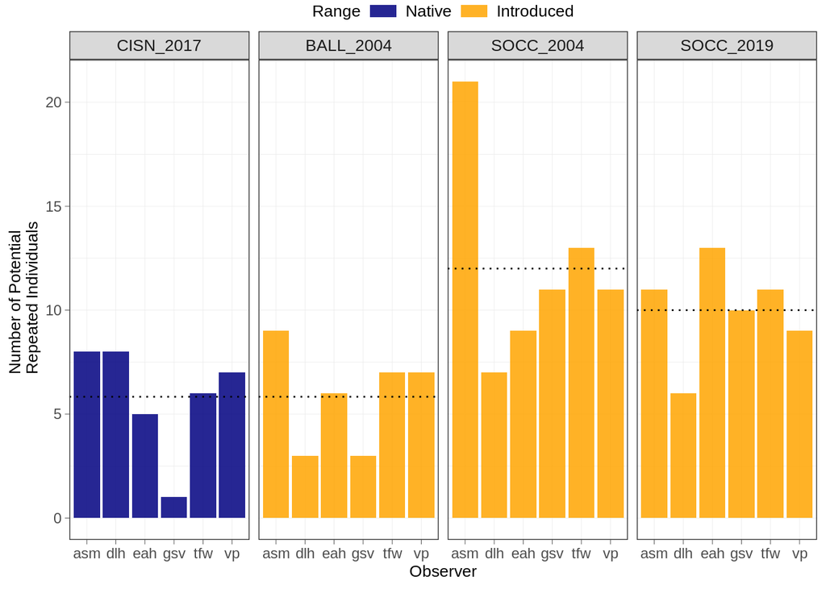

```r
multi_obsv %>%
  dplyr::mutate(
    site_year = as.character(site_year),
    range = ifelse(grepl("CISN", site_year), "Native", "Introduced"),
    site_year = factor(site_year, levels = c("CISN_2017", "BALL_2004", "SOCC_2004", "SOCC_2019")),
    range = factor(range, levels = c("Native", "Introduced"))
  ) %>%
  # Remove class_0, which was reserved for calls from "unique" individuals
  dplyr::filter(class != "class_0") %>%
  # Only retain potental repeated individuals that were assigned more than one call
  group_by(range, site_year, observer, class) %>%
  dplyr::summarise(n_calls = length(call)) %>%
  ungroup() %>%
  dplyr::filter(n_calls > 1) %>%
  group_by(range, site_year, observer) %>%
  dplyr::summarise(num_pot_rep_indiv = n_distinct(class)) %>%
  ungroup() %>%
  ggplot(aes(x = observer, y = num_pot_rep_indiv)) +
  geom_col(aes(fill = range)) +
  facet_grid(~ site_year) +
  geom_hline(data = dum_df, aes(yintercept = mean_indivs), linetype = "dotted", color = "black", size = 0.5) +
  scale_fill_manual(values = fills) +
  guides(fill = guide_legend(title = "Range")) +
  xlab("Observer") +
  ylab("Number of Potential \n Repeated Individuals") +
  # guides(fill = guide_legend(override.aes = list(size = 0.1))) +
  theme_bw() +
  theme(
    strip.text = element_text(size = 10),
    axis.title = element_text(size = 10),
    axis.text = element_text(size = 9),
    panel.grid.major = element_line(size = 0.15),
    panel.grid.minor = element_line(size = 0.15),
    axis.ticks = element_line(size = 0.15),
    legend.position = "top",
    legend.key.height = unit(0.35, "line"),
    legend.title = element_text(size = 10),
    legend.text = element_text(size = 10),
    legend.margin = margin(2, 2, 2, 2),
    legend.box.margin = margin(-5, -5, -5, -5)
  )
```

# Summary statistics for the main text

Did we identify more potential repeated individuals for the introduced range, and more calls per each of these individuals? Get the potential repeated individuals across users.

```r
file_nms <- list.files(pattern = ".json$", path)
file_nms
```

```
## [1] "asm-2020-04-09_19-12-47.json" "dlh-2020-04-28_14-23-46.json"
## [3] "eah-2020-04-10_12-25-58.json" "gsv-2020-04-23_09-39-43.json"
## [5] "tfw-2020-05-07_20-34-18.json" "vp-2020-05-18_18-50-40.json"
```

```r
users <- sapply(1:length(file_nms), function(i){
  strsplit(file_nms[i], split = "-")[[1]][1]
})
users
```

```
## [1] "asm" "dlh" "eah" "gsv" "tfw" "vp"
```

```r
# x <- 1
# i <- 12
# z <- 1
user_res_df <- rbindlist(pblapply(1:length(users), function(x){

  res <- list.load(file.path(path, file_nms[x]))
  # str(res)

  sy <- names(res[["Testing"]])

  # i <- 1
  res_df <- rbindlist(lapply(1:length(sy), function(i){

    # Bind list objects together into a wide data frame
    tmp_df <- do.call("cbind.data.frame", res[["Testing"]][[sy[i]]][[1]])
    # glimpse(tmp_df)

    # Convert to long format ot facilitate combining results across users
    tmp_df2 <- tmp_df %>%
      pivot_longer(cols = names(tmp_df)[grep("class_0|Potential_Individual", names(tmp_df))], names_to = "Class", values_to = "Call_image_files") %>%
      dplyr::mutate(
        Call_image_files = as.character(Call_image_files)
      )

    # glimpse(tmp_df2)

    # Iterate over potential repeated individuals and return all calls
    # z <- 1
    tmp_df3 <- rbindlist(lapply(1:nrow(tmp_df2), function(z){

      # Extract the individual filenames, remove the "-1.jpeg" suffix for grepping in EST later
      calls <- gsub("-1.jpeg$", "", strsplit(tmp_df2$Call_image_files[z], split = ";")[[1]])
      # calls

      # Return a data frame that has one row per call
      return(data.frame(login_username = tmp_df2$login_username[z], site_year = tmp_df2$page[z], Class = tmp_df2$Class[z], sound.files = calls))

    }))

    return(tmp_df3)

  }))

  return(res_df)

}))

glimpse(user_res_df)
```

```
## Rows: 2,198
## Columns: 4
## $ login_username <chr> "asm", "asm", "asm", "asm", "asm", "asm", "asm", "asm",…
## $ site_year      <chr> "RIAC_2017", "RIAC_2017", "RIAC_2017", "RIAC_2017", "RI…
## $ Class          <chr> "Potential_Individual_1", "Potential_Individual_1", "Po…
## $ sound.files    <chr> "2017_06_28_RIAC-01_1049_7.WAV", "2017_06_28_RIAC-01_10…
```

```r
# user_res_df %>%
# View()
```

## Repeated individual summary statistics per range

```r
# Get number of calls per range from Shiny prediction module calls
# Note that there's one unique sound file per row, multiobserver sites were encoded with all observer names in the co-author column
shiny_prediction_module_est <- readRDS(file.path(path, "shiny_potrepindiv_prediction_module_est.RDS")) %>%
  dplyr::mutate(
    range = gsub("Invasive", "Introduced", range)
  )
glimpse(shiny_prediction_module_est)
```

```
## Rows: 1,113
## Columns: 29
## $ sound.files          <chr> "2017_05_07_ARAP_1003_1.WAV", "2017_05_07_ARAP_10…
## $ selec                <dbl> 1, 1, 1, 1, 1, 1, 1, 1, 1, 1, 1, 1, 1, 1, 1, 1, 1…
## $ start                <dbl> 0.05, 0.05, 0.05, 0.05, 0.05, 0.05, 0.05, 0.05, 0…
## $ end                  <dbl> 0.2489708, 0.2313345, 0.2196348, 0.2199983, 0.212…
## $ date                 <date> 2017-05-07, 2017-05-07, 2017-05-07, 2017-05-07, …
## $ range                <chr> "Native", "Native", "Native", "Native", "Native",…
## $ social_scale         <chr> "Site", "Site", "Site", "Site", "Site", "Site", "…
## $ site                 <chr> "ARAP", "ARAP", "ARAP", "ARAP", "ARAP", "ARAP", "…
## $ Bird_ID              <chr> NA, NA, NA, NA, NA, NA, NA, NA, NA, NA, NA, NA, N…
## $ lat                  <dbl> -30.94636, -30.94636, -30.94636, -30.94636, -30.9…
## $ lon                  <dbl> -57.51980, -57.51980, -57.51980, -57.51980, -57.5…
## $ Visual_quality_score <fct> H, H, M, M, H, H, M, H, H, H, H, H, H, H, M, H, M…
## $ Overlapping_signal   <fct> N, N, N, N, N, N, N, N, N, N, N, N, N, N, N, N, N…
```

[output cut: 16 more lines]

```r
shiny_prediction_module_est %>%
  pull(range) %>%
  unique()
```

```
## [1] "Native"     "Introduced"
```

```r
# The number of sites per range used for these summary statistics
shiny_prediction_module_est %>%
  dplyr::filter(!site_year %in% c("CISN_2017", "BALL_2004", "SOCC_2004", "SOCC_2019")) %>%
  distinct(range, site_year) %>%
  group_by(range) %>%
  dplyr::summarise(
    n_site_years = n()
  )
```

```
## # A tibble: 2 × 2
##   range      n_site_years
##   <chr>             <int>
## 1 Introduced           22
## 2 Native               36
```

### Gaussian mixture modelling

How many potential repeated individuals were identified on average per range by Gaussian mixture modeling? Here, find unique potential repeated individuals (clusters) that have more than one call, then get mean and standard error of the number of repeated individuals identified across site-years and range per range.

```r
# Not grouping here by co-author initials since I'm interested in statistics prior to classification, but drop the multiobserver sites for now
# Get unique potential repeated individuals that have more than one call
shiny_prediction_module_est %>%
  dplyr::filter(!site_year %in% c("CISN_2017", "BALL_2004", "SOCC_2004", "SOCC_2019")) %>%
  # Get the number of calls assigned to each cluster identified per range and site-year
  group_by(range, site_year, cluster) %>%
  dplyr::summarise(
    n_calls = length(sound.files)
  ) %>%
  # Retain clusters that were assigned more than 1 call
  dplyr::filter(n_calls > 1) %>%
  # Rejoin to the full data frame to regain sound files
  inner_join(
    shiny_prediction_module_est %>%
      dplyr::filter(!site_year %in% c("CISN_2017", "BALL_2004", "SOCC_2004", "SOCC_2019")),
    by = c("range", "site_year", "cluster")
  ) %>%
  # How many clusters were identified per site-year?
  group_by(range, site_year) %>%
  dplyr::summarise(
    n_clust = n_distinct(cluster)
  ) %>%
  # Mean and standard error per range?
  group_by(range) %>%
  dplyr::summarise(
    mean_clusters = round(mean(n_clust), 2),
    se_clusters = round(std_err(n_clust), 2)
  )
```

```
## # A tibble: 2 × 3
##   range      mean_clusters se_clusters
##   <chr>              <dbl>       <dbl>
## 1 Introduced          3.23        0.51
## 2 Native              3.14        0.37
```

How calls were attributed to potential repeated individuals were identified on average per range by Gaussian mixture modeling? Here, find unique potential repeated individuals (clusters) that have more than one call, then get mean and standard error of the number calls attributed to repeated individuals identified across site-years and range per range.

```r
shiny_prediction_module_est %>%
  dplyr::filter(!site_year %in% c("CISN_2017", "BALL_2004", "SOCC_2004", "SOCC_2019")) %>%
  # Get the number of calls assigned to each cluster identified per range and site-year
  group_by(range, site_year, cluster) %>%
  dplyr::summarise(
    n_calls = length(sound.files)
  ) %>%
  # Retain clusters that were assigned more than 1 call
  dplyr::filter(n_calls > 1) %>%
  # Rejoin to the full data frame to regain sound files
  inner_join(
    shiny_prediction_module_est %>%
      dplyr::filter(!site_year %in% c("CISN_2017", "BALL_2004", "SOCC_2004", "SOCC_2019")),
    by = c("range", "site_year", "cluster")
  ) %>%
  # How many clusters were identified per site-year?
  group_by(range, site_year) %>%
  dplyr::summarise(
    n_calls = length(sound.files)
  ) %>%
  # Mean and standard error per range?
  group_by(range) %>%
  dplyr::summarise(
    mean_calls = round(mean(n_calls), 2),
    se_calls = round(std_err(n_calls), 2)
  )
```

```
## # A tibble: 2 × 3
##   range      mean_calls se_calls
##   <chr>           <dbl>    <dbl>
## 1 Introduced       18.0     4.75
## 2 Native           10       1.6
```

### Visual classification

How many total potential repeated individuals were identified on average per range during visual classification? Here, find unique potential repeated individuals that have more than one call.

Total number of potential repeated individuals identified per range.

```r
glimpse(user_res_df)
```

```
## Rows: 2,198
## Columns: 4
## $ login_username <chr> "asm", "asm", "asm", "asm", "asm", "asm", "asm", "asm",…
## $ site_year      <chr> "RIAC_2017", "RIAC_2017", "RIAC_2017", "RIAC_2017", "RI…
## $ Class          <chr> "Potential_Individual_1", "Potential_Individual_1", "Po…
## $ sound.files    <chr> "2017_06_28_RIAC-01_1049_7.WAV", "2017_06_28_RIAC-01_10…
```

```r
# Checking: After dropping the sites assessed across observers, each site-year represents a unique site-year and observer combination. Looks good
user_res_df %>%
  dplyr::filter(!site_year %in% c("CISN_2017", "BALL_2004", "SOCC_2004", "SOCC_2019")) %>%
  distinct(login_username, site_year)
```

```
##     login_username    site_year
##  1:            asm    RIAC_2017
##  2:            asm INES-08_2017
##  3:            asm    ECIL_2017
##  4:            asm    PAVO_2017
##  5:            asm    OJOS_2017
##  6:            asm    VALL_2011
##  7:            asm    AIRP_2019
##  8:            asm    AUDU_2004
##  9:            dlh    PFER_2017
## 10:            dlh INES-07_2017
## 11:            dlh    ROSA_2017
## 12:            dlh    SAUC_2017
## 13:            dlh    BAGU_2017
## 14:            dlh    KIYU_2017
```

[output cut: 45 more lines]

```r
# The number of sites per range used for these summary statistics
user_res_df %>%
  dplyr::filter(!site_year %in% c("CISN_2017", "BALL_2004", "SOCC_2004", "SOCC_2019")) %>%
  inner_join(
    nat_int_est %>%
      as_tibble() %>%
      dplyr::select(c(range, sound.files)),
    by = "sound.files"
  ) %>%
  distinct(range, site_year) %>%
  group_by(range) %>%
  dplyr::summarise(
    n_site_years = n()
  )
```

```
## # A tibble: 2 × 2
##   range      n_site_years
##   <chr>             <int>
## 1 Introduced           22
## 2 Native               36
```

Mean and standard error of the number of potential repeatedly sampled individuals across site-years per range.

```r
user_res_df %>%
  dplyr::filter(!site_year %in% c("CISN_2017", "BALL_2004", "SOCC_2004", "SOCC_2019")) %>%
  # Drop class_0 calls
  dplyr::filter(Class != "class_0") %>%
  inner_join(
    nat_int_est %>%
      as_tibble() %>%
      dplyr::select(c(range, sound.files)),
    by = "sound.files"
  ) %>%
  dplyr::mutate(
    uniq_id = paste(range, site_year, Class, sep = "_")
  ) %>%
  group_by(range, site_year, uniq_id) %>%
  dplyr::summarise(
    n_calls = length(sound.files)
  ) %>%
  ungroup() %>%
  dplyr::filter(n_calls > 1) %>%
  group_by(range, site_year) %>%
  dplyr::summarise(
    n_pot_rep_indivs = length(uniq_id)
  ) %>%
  group_by(range) %>%
  dplyr::summarise(
    mean_npri = round(mean(n_pot_rep_indivs), 2),
    se_npri = round(std_err(n_pot_rep_indivs), 2)
  )
```

```
## # A tibble: 2 × 3
##   range      mean_npri se_npri
##   <chr>          <dbl>   <dbl>
## 1 Introduced      3.57    0.54
## 2 Native          3.48    0.39
```

Mean and standard error of the number of calls per potential repeatedly sampled individuals across site-years per range.

```r
user_res_df %>%
  dplyr::filter(!site_year %in% c("CISN_2017", "BALL_2004", "SOCC_2004", "SOCC_2019")) %>%
  # Drop class_0 calls
  dplyr::filter(Class != "class_0") %>%
  inner_join(
    nat_int_est %>%
      as_tibble() %>%
      dplyr::select(c(range, sound.files)),
    by = "sound.files"
  ) %>%
  dplyr::mutate(
    uniq_id = paste(range, site_year, Class, sep = "_")
  ) %>%
  group_by(range, site_year, uniq_id) %>%
  dplyr::summarise(
    n_calls = length(sound.files)
  ) %>%
  ungroup() %>%
  dplyr::filter(n_calls > 1) %>%
  group_by(range) %>%
  dplyr::summarise(
    mean_calls = round(mean(n_calls), 2),
    se_calls = round(std_err(n_calls), 2)
  )
```

```
## # A tibble: 2 × 3
##   range      mean_calls se_calls
##   <chr>           <dbl>    <dbl>
## 1 Introduced       5.31     0.64
## 2 Native           2.83     0.15
```

More calls were attributed to potential repeated indivduals in the introduced range. But could this be due to some observers handling more introduced range site-years than others? The number of site-years assessed per observer should have been pretty similar given our random sampling.

```r
# Similar numbers of site-years were assessed per range across observers
user_res_df %>%
  dplyr::filter(!site_year %in% c("CISN_2017", "BALL_2004", "SOCC_2004", "SOCC_2019")) %>%
  inner_join(
    nat_int_est %>%
      dplyr::select(c(range, sound.files)),
    by = "sound.files"
  ) %>%
  group_by(range, login_username) %>%
  dplyr::summarise(
    num_sy = n_distinct(site_year)
  ) %>%
  pivot_wider(
    names_from = "range",
    values_from = "num_sy"
  )
```

```
## # A tibble: 6 × 3
##   login_username Introduced Native
##   <chr>               <int>  <int>
## 1 asm                     3      5
## 2 dlh                     4      6
## 3 eah                     3      6
## 4 gsv                     5      7
## 5 tfw                     3      6
## 6 vp                      4      6
```

Mean and standard error of site-years assessed across observers per range.

```r
user_res_df %>%
  dplyr::filter(!site_year %in% c("CISN_2017", "BALL_2004", "SOCC_2004", "SOCC_2019")) %>%
  inner_join(
    nat_int_est %>%
      dplyr::select(c(range, sound.files)),
    by = "sound.files"
  ) %>%
  group_by(range, login_username) %>%
  dplyr::summarise(
    num_sy = n_distinct(site_year)
  ) %>%
  dplyr::summarise(
    mean_sy = round(mean(num_sy), 2),
    se_sy = round(std_err(num_sy), 2)
  )
```

```
## # A tibble: 2 × 3
##   range      mean_sy se_sy
##   <chr>        <dbl> <dbl>
## 1 Introduced    3.67  0.33
## 2 Native        6     0.26
```

# References

```
1. Smith-Vidaurre, G., Araya-Salas, M., and T.F. Wright. 2020. Individual signatures outweigh social group identity in contact calls of a communally nesting parrot. Behavioral Ecology 31(2), 448-458. https://doi.org/10.1093/beheco/arz202

2. Smith-Vidaurre, G., Perez-Marrufo, V., & Wright, T. F. 2021. Individual vocal signatures show reduced complexity following invasion. Animal Behavior, 179, 15–39. https://doi.org/10.1016/j.anbehav.2021.06.020
```